# R Notebook

# An?lisis Multivariado de Valores Extremos

```r
#-------------------------------------------------------#
# Ejemplo: Outliers en dos dimensiones                  #
#-------------------------------------------------------#

load(file = "simpleExample.rda")
#load(file.choose())
head(dat)
```

```
              x           y
[1,]  0.5543269 -0.50947340
[2,] -0.2802719 -0.97869138
[3,]  1.7751634  1.35085424
[4,]  0.1873201  0.36816416
[5,]  1.1425261  0.07362472
[6,]  0.4155261  0.44918115
```

```r
tail(dat)
```

```
                x          y
[296,] -1.2849140 -0.5436269
[297,] -0.4485976  0.5322208
[298,] -1.5896048 -0.1536769
[299,] -1.2560158 -2.1614296
[300,] -0.1068436  0.6288747
[301,] -3.0000000  3.0000000
```

```r
summary(dat)
```

```
       x                  y
 Min.   :-3.00000   Min.   :-2.808120
 1st Qu.:-0.84697   1st Qu.:-0.566137
 Median :-0.07606   Median : 0.033304
 Mean   :-0.08099   Mean   : 0.008512
 3rd Qu.: 0.61150   3rd Qu.: 0.613846
 Max.   : 2.90569   Max.   : 3.464020
```

```r
par(mfrow=c(1,3))
plot(dat, xlim = c(-5,5), ylim = c(-5,5))
barplot(dat[,1], main="Valores de X")
```

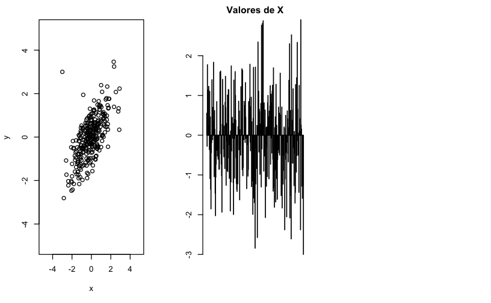

```r
barplot(dat[,2], main="Valores de Y")
par(mfrow=c(1,1))
```

[output not shown]

```r
par(mfrow=c(1,3))
plot(dat, xlim = c(-5,5), ylim = c(-5,5))
boxplot(dat[,1],main="Valores de X")
```

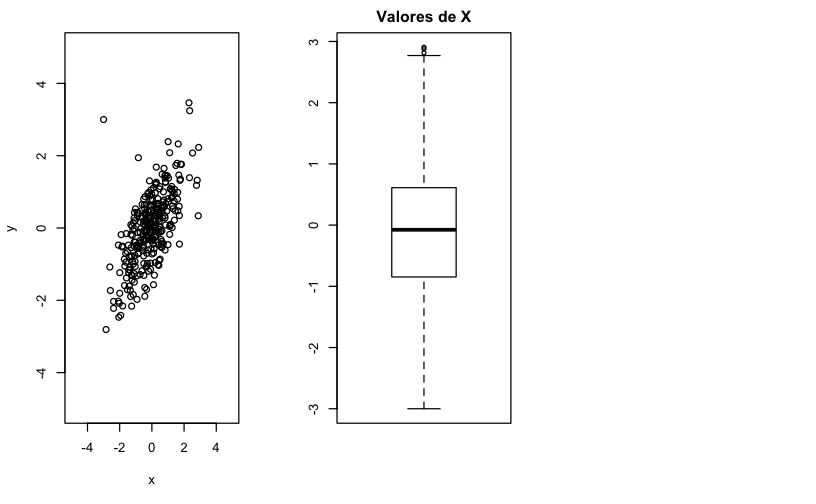

```r
boxplot(dat[,2],main="Valores de y")
par(mfrow=c(1,1))
```

[output not shown]

Se obseva un outlier en la primera grafica , aproximadamente en la posicion (-3,3)

# Cuando tengo mas de 2 variables ya no se puede buscar los outliers visualmente

```r
# Distancia de Mahalanobis
cm <- colMeans(dat)
S <- cov(dat)
dm <- sqrt(apply(dat, 1, function(x) t(x-cm) %*% solve(S) %*% (x-cm)))

# Matriz de varianza covarianza
S
```

```
          x         y
x 1.1378188 0.7057616
y 0.7057616 1.0076415
```

```r
# Distancia de Mahalanobis cuadrada
d <- dm^2

# Se visualiza el valor calculado
d
```

```
  [1]  1.81443428  1.34359753  3.09200963  0.12878685  2.16034467
  [6]  0.24756251  1.69924437  1.82198803  1.53497953  2.72468778
 [11]  1.54242046  1.21463303  1.59249199  3.33496174  5.03592126
 [16]  1.92592963  2.80143713  0.17378408  0.05056736  0.56419064
 [21]  0.17627359  3.78618957  0.94759327  0.86800907  0.90628959
 [26]  0.08115461  1.91231169  4.70006071  1.97556945  0.50070373
 [31]  1.34960442  1.59271835  0.56921614  0.42458648  0.12051688
 [36]  1.89284302  4.26537564  0.53630711  1.89506733  0.52285825
 [41]  5.03805092  2.56053356  1.29773893  3.12583990  1.46877372
 [46]  0.36655951  0.84239816  5.88071363  1.98819986  1.98264391
 [51]  3.82725003  2.82496820  0.06678268  0.32234062  0.13446490
 [56]  1.50950471 10.66490607  2.08761899  3.14079049  0.56506678
 [61]  1.23173715  0.24322774  3.13864392  1.79411776  1.05536410
 [66]  4.36959031  0.21417811  2.12847910  1.48726747  0.38184603
 [71]  0.90829063  0.63771615  0.27359809  4.48807839  1.73353639
```

[output cut: 46 more lines]

La distancia que tiene el primer dato con su centroide es:

[1] 1.81443428

Se observa que la ultima observacion tiene un potencial de ser un outlier en comparacion con los otros datos

[301] 47.95357800

```r
# Se obtine el valro de mahalanobis al cuadrado
d <- mahalanobis(dat, cm, S)
d
```

```
  [1]  1.81443428  1.34359753  3.09200963  0.12878685  2.16034467
  [6]  0.24756251  1.69924437  1.82198803  1.53497953  2.72468778
 [11]  1.54242046  1.21463303  1.59249199  3.33496174  5.03592126
 [16]  1.92592963  2.80143713  0.17378408  0.05056736  0.56419064
 [21]  0.17627359  3.78618957  0.94759327  0.86800907  0.90628959
 [26]  0.08115461  1.91231169  4.70006071  1.97556945  0.50070373
 [31]  1.34960442  1.59271835  0.56921614  0.42458648  0.12051688
 [36]  1.89284302  4.26537564  0.53630711  1.89506733  0.52285825
 [41]  5.03805092  2.56053356  1.29773893  3.12583990  1.46877372
 [46]  0.36655951  0.84239816  5.88071363  1.98819986  1.98264391
 [51]  3.82725003  2.82496820  0.06678268  0.32234062  0.13446490
 [56]  1.50950471 10.66490607  2.08761899  3.14079049  0.56506678
 [61]  1.23173715  0.24322774  3.13864392  1.79411776  1.05536410
 [66]  4.36959031  0.21417811  2.12847910  1.48726747  0.38184603
 [71]  0.90829063  0.63771615  0.27359809  4.48807839  1.73353639
```

[output cut: 46 more lines]

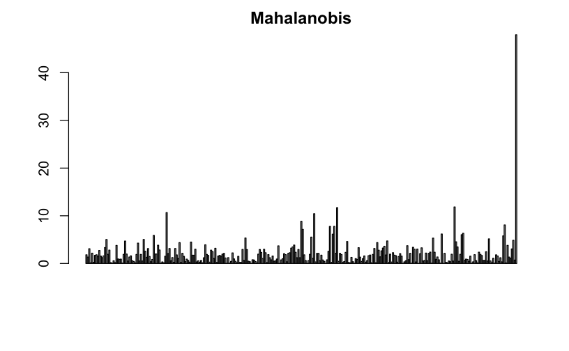

```r
barplot(d, main="Mahalanobis")
```

```r
which.max(d)
```

```
[1] 301
```

Visualmente se observa que hay la ultima vertical tiene el mayor valor y puede ser un outlier.

```
integer(0)
```

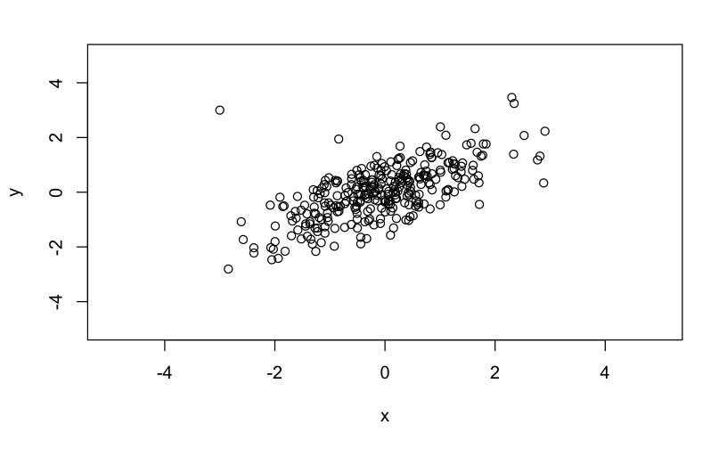

```r
plot(dat, xlim = c(-5,5), ylim = c(-5,5))
identify(dat[,1], dat[,2],round(d,1)) # permite ver las observaciones en el grafico con la tecla ESC para verlo
```

Si la distribucion viniera de una CHi2 con 2 grado de libertad entonces podria construir una grafica de Cuantil vs Cuantil

```
      |                 . .
      |                 .. .
      |            . ..
      |         ....
```

```
        Cuantiles empiricas
```

Si se observa desviacion , entonces se puede ver que la grafica no venga de la distribucion

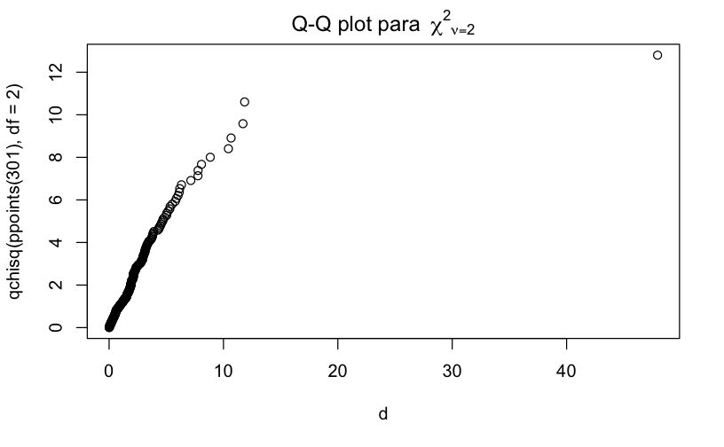

```r
# d : distancia de Mahalanobis
# Se pone 301

#  QQ-plot:
qqplot(d, qchisq(ppoints(301), df = 2),
       main = expression("Q-Q plot para" ~~ {chi^2}[nu == 2]))
```

Se observa que hay un potencial outlier

```r
head(ppoints(301))
```

```
[1] 0.001661130 0.004983389 0.008305648 0.011627907 0.014950166 0.018272425
```

```r
head(sort(d))
```

```
[1] 0.01314332 0.01394860 0.01691404 0.01819407 0.01827400 0.02197908
```

```r
qchisq(0.01314332,2) # calculamos el valor teorico con 2 grados de libertad
```

```
[1] 0.02646092
```

```r
qnorm(0.1,12,2) # Calculo el quantil 0.1 para una media de 12 y std 2
```

```
[1] 9.436897
```

Es la nota que se esperaria para el quantil 0.1

# Se grafica las ojivas

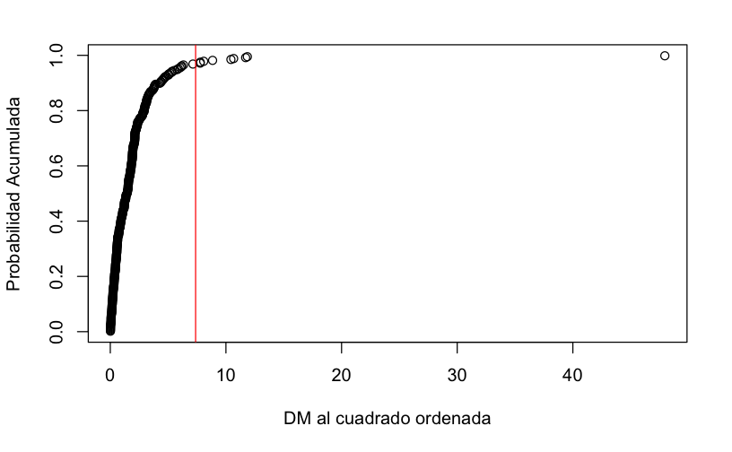

```r
plot(sort(d), ppoints(301), xlab ="DM al cuadrado ordenada", ylab = "Probabilidad Acumulada")
Q <- qchisq(p = 0.975, df = 2)
abline(v=Q, col = "red")
```

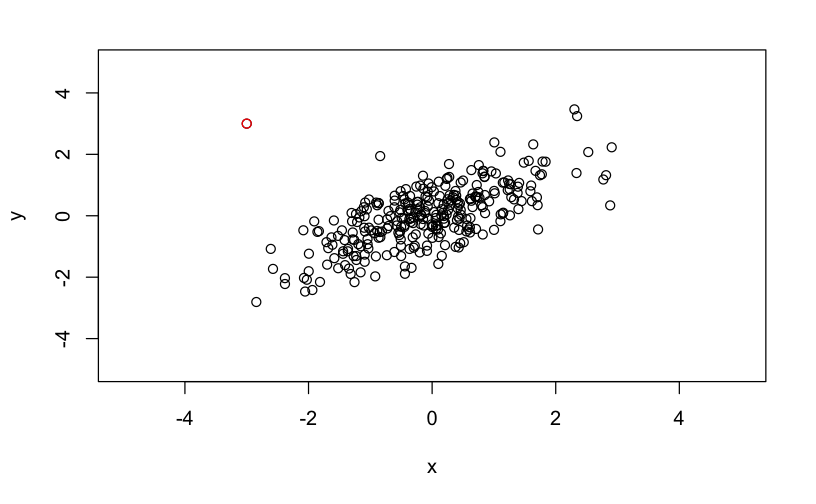

```r
par(mfrow = c(1,1))
plot(dat, xlim=c(-5,5), ylim=c(-5,5))
points(dat[301,1],dat[301,2],col="red")
```

Se marca el potencial outlier